# Challenge 2 Notebook

Jake Garmo, Joshua Weimer, Lilly Amirjavadi, Cole Evarts

3/7/2021

### libraries

```r
library(stm)
library(tidyverse)
library(tm)
library(Matrix)
library(quanteda.textmodels)
library(quanteda)
```

```r
library(dplyr)
library(ggplot2)
```

### We seperated coding responsibilities into two parts which is why the code is using different data objects and seems like it is written by different people. The code was compiled into an html doc on one computer

# Part 1, news sentiment

```r
#load data
emails <- read.csv("C:/Users/garmo/Downloads/Emails.csv")
Clinton <- read.csv("C:/Users/garmo/Downloads/Clinton.csv", header=TRUE)

df <- Clinton
```

```r
#testing extracting terms from subject lines

#x <- grepl("DAILY BEAST",df$Subject)
#df$Subject[x]
```

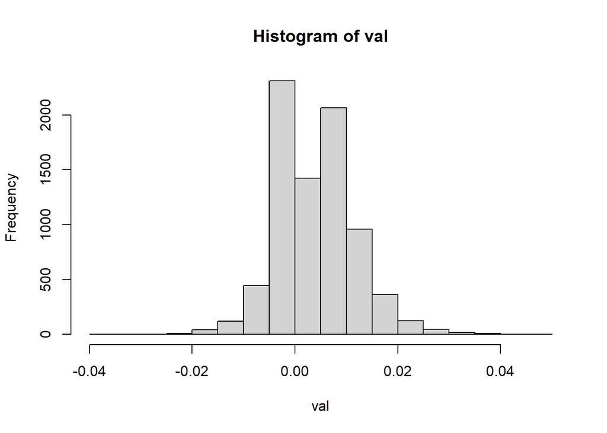

```r
#load in libraires of negative and positive term words
neg <- unlist(read.table("C:/Users/garmo/Downloads/negative-words.txt", stringsAsFactors = F))
pos <- unlist(read.table("C:/Users/garmo/Downloads/positive-words.txt", stringsAsFactors = F))

# Create weight vector corresponding to all words in matrix
words <- colnames(df)
theta <- (1*as.numeric(words %in% pos)) +
  (-1*as.numeric(words %in% neg))

 ##sentiment for all docs
val <- apply(df[,-(1:10)], MARGIN = 1, FUN = function(z) sum(z*theta)/sum(z))
hist(val)
```

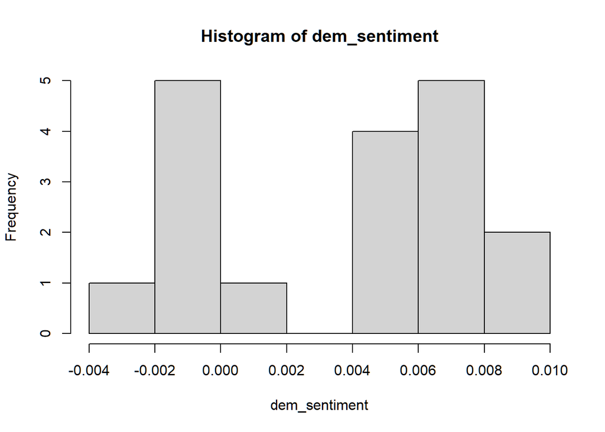

```r
#sentiment of democrat/liberal in email subject
dem_emails <- grepl("LEFT|DEMOCRAT|LIBERAL|DNC",df$Subject)
dem_sentiment <- apply(df[dem_emails,-(1:10)], MARGIN = 1, FUN = function(z) sum(z*theta)/sum(z))
hist(dem_sentiment)
```

```r
mean(dem_sentiment)
```

```
## [1] 0.004013756
```

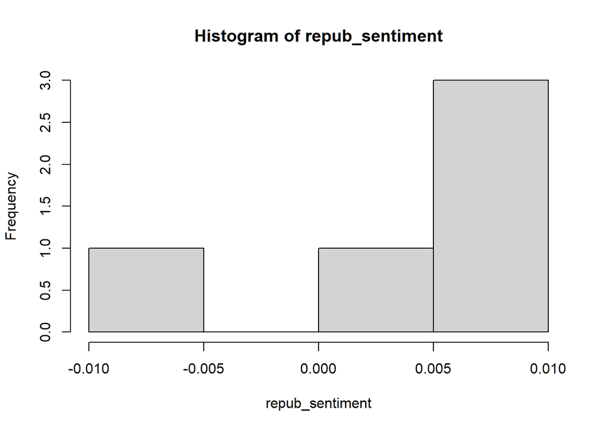

```r
#sentiment of republican/conservative in email subject
repub_emails <- grepl("REPUBLICAN|CONSERVATIVE|RNC",df$Subject)
repub_sentiment <- apply(df[repub_emails,-(1:10)], MARGIN = 1, FUN = function(z) sum(z*theta)/sum(z))
hist(repub_sentiment)
```

```r
mean(repub_sentiment)
```

```
## [1] 0.003479173
```

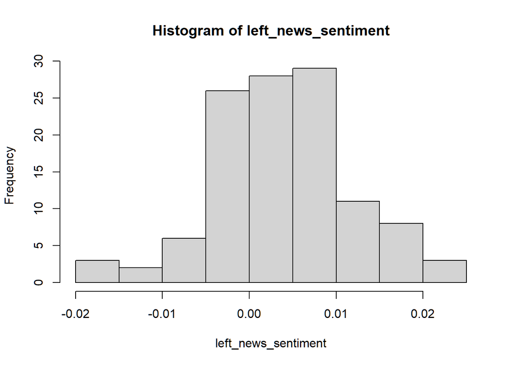

```r
#bias is determined by the AllSides media chart
# https://www.allsides.com/media-bias/media-bias-chart
#left leaning sources include "Left" and "Lean Left" on the chart
#the only right lening source that could be found in the dataset was Fox

#sentiment of all left leaning news sources

left_news <- grepl("CNN|HUFFINGTON|BUZZFEED|MSNBC|NYT|VOX|HUFFPOST|BLOOMBERG|ECONOMIST|NPR|POLITICO|DAILY BEAST",df$Subject)
left_news_sentiment <- apply(df[left_news,-(1:10)], MARGIN = 1, FUN = function(z) sum(z*theta)/sum(z))
hist(left_news_sentiment)
```

```r
mean(left_news_sentiment)
```

```
## [1] 0.004438418
```

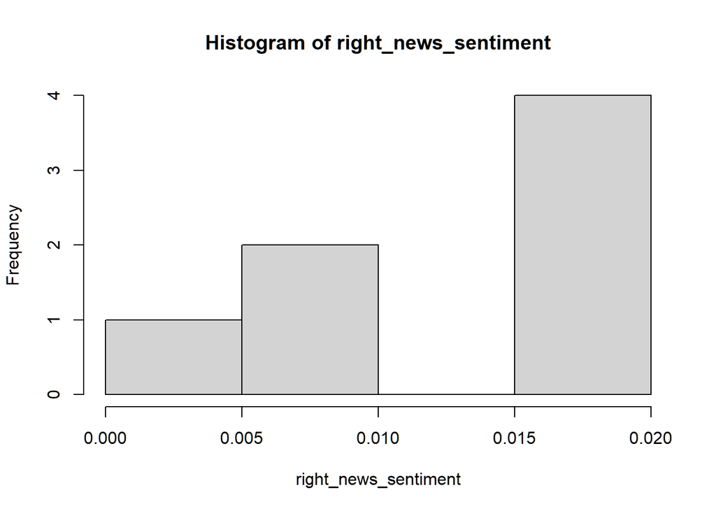

```r
#sentiment of Fox (only conservative media source)

right_news <- grepl("FOX",df$Subject)
right_news_sentiment <- apply(df[right_news,-(1:10)], MARGIN = 1, FUN = function(z) sum(z*theta)/sum(z))
hist(right_news_sentiment)
```

```r
mean(right_news_sentiment)
```

```
## [1] 0.01262772
```

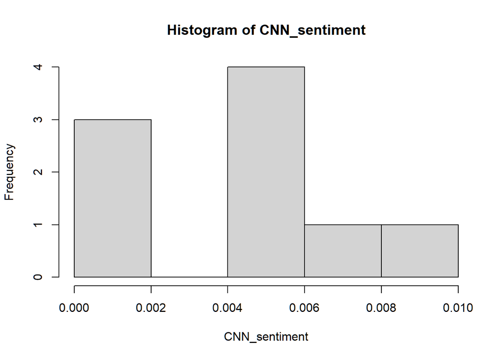

```r
#sentiment of just CNN

CNN <- grepl("CNN",df$Subject)
CNN_sentiment <- apply(df[CNN,-(1:10)], MARGIN = 1, FUN = function(z) sum(z*theta)/sum(z))
hist(CNN_sentiment)
```

```r
mean(CNN_sentiment)
```

```
## [1] 0.00401105
```

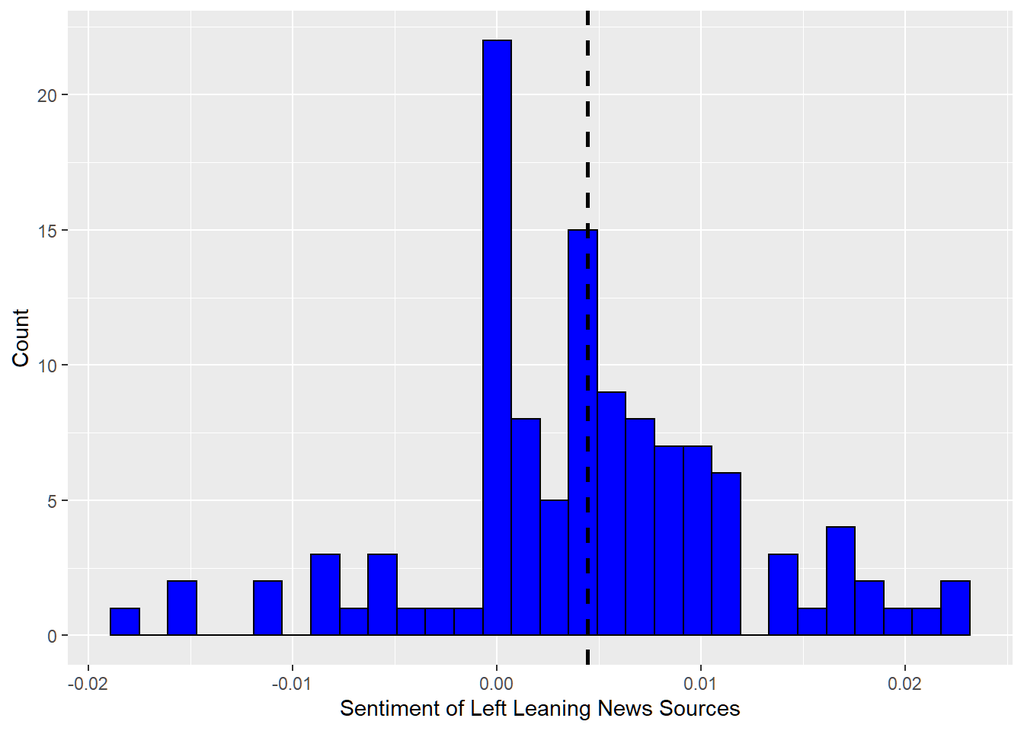

```r
#make some nicer histograms

library(ggplot2)



#left_news_sentiment
ggplot() + aes(left_news_sentiment)+ geom_histogram(colour="black", fill="blue") + geom_vline(aes(xintercept=mean(left_news_sentiment)),
            color="black", linetype="dashed", size=1) +
  labs(x="Sentiment of Left Leaning News Sources", y = "Count")
```

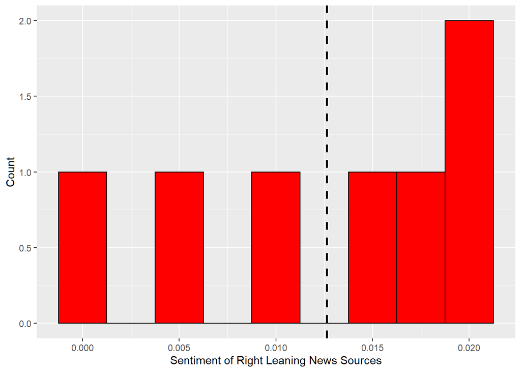

```r
#right_news_sentiment
ggplot() + aes(right_news_sentiment)+ geom_histogram(colour="black", fill="red", binwidth = 0.0025) + geom_vline(aes(xintercept=mean(right_news_sentiment)),
            color="black", linetype="dashed", size=1) +
  labs(x="Sentiment of Right Leaning News Sources", y = "Count")
```

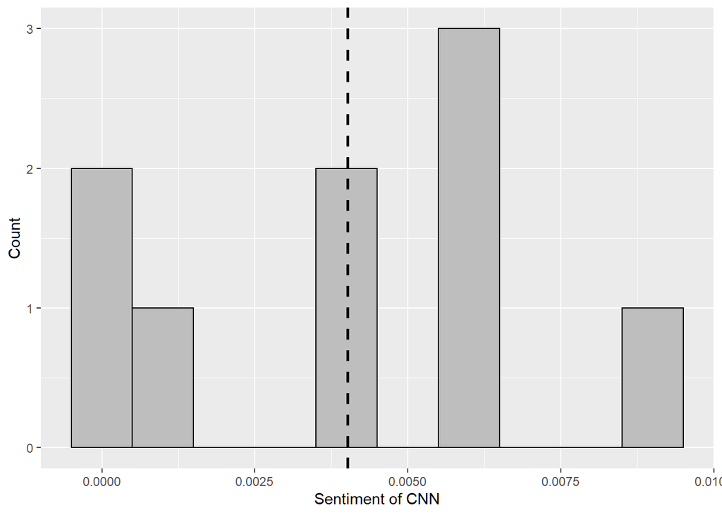

```r
#cnn_sentiment
ggplot() + aes(CNN_sentiment)+ geom_histogram(colour="black", fill="grey", binwidth = 0.001) + geom_vline(aes(xintercept=mean(CNN_sentiment)),
            color="black", linetype="dashed", size=1) +
  labs(x="Sentiment of CNN", y = "Count")
```

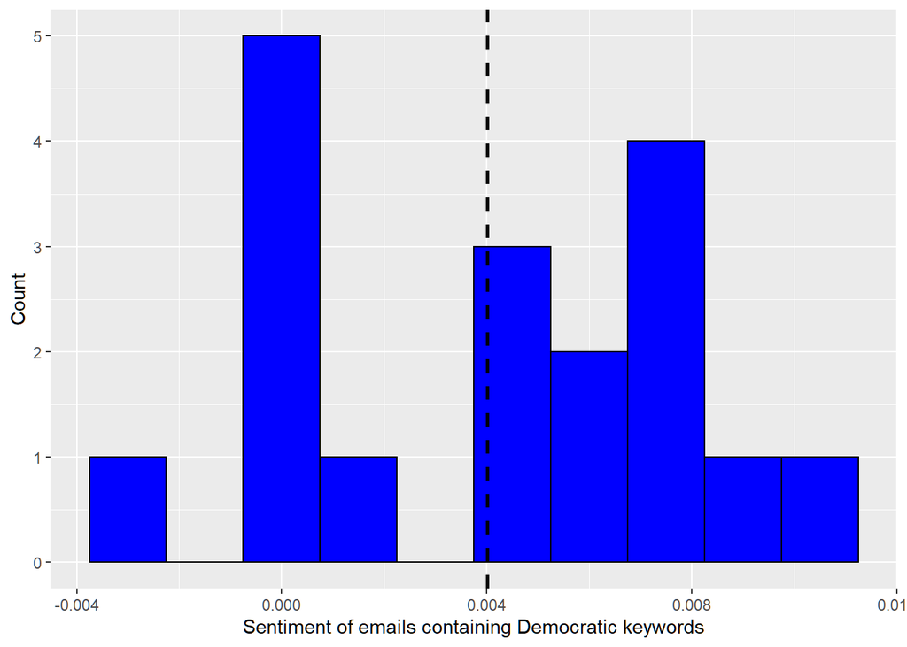

```r
#dem sentiment

ggplot() + aes(dem_sentiment)+ geom_histogram(colour="black", fill="blue", binwidth = 0.0015) + geom_vline(aes(xintercept=mean(dem_sentiment)),
            color="black", linetype="dashed", size=1) +
  labs(x="Sentiment of emails containing Democratic keywords", y = "Count")
```

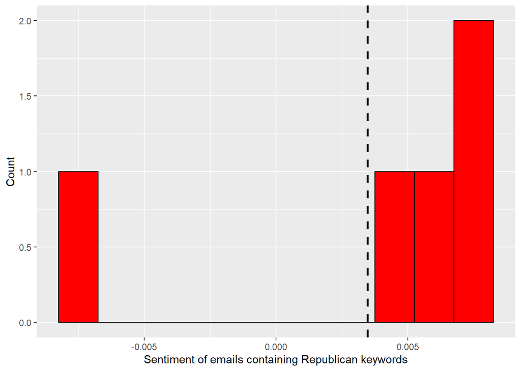

```r
#repub_sentiment
ggplot() + aes(repub_sentiment)+ geom_histogram(colour="black", fill="red", binwidth = 0.0015) + geom_vline(aes(xintercept=mean(repub_sentiment)),
            color="black", linetype="dashed", size=1)+
  labs(x="Sentiment of emails containing Republican keywords", y = "Count")
```

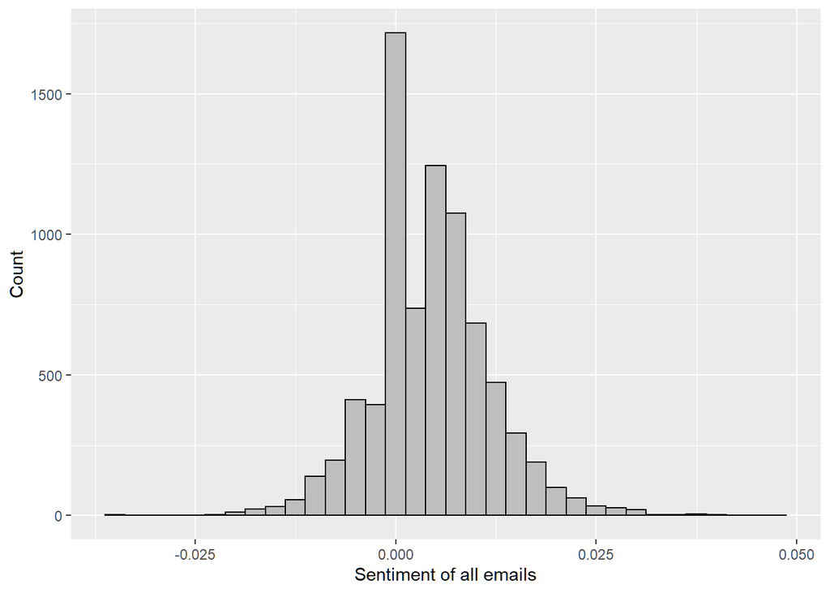

```r
#sentiment of all emails

ggplot() + aes(val)+ geom_histogram(colour="black", fill="grey", binwidth = 0.0025) + geom_vline(aes(xintercept=mean(val)),
            color="black", linetype="dashed", size=1)+
  labs(x="Sentiment of all emails", y = "Count")
```

# Part 2 Topic Modeling and Sentiment per Topic

## Import data

```r
emails <- read.csv("C:/Users/garmo/Downloads/Emails.csv")
Clinton <- read.csv("C:/Users/garmo/Downloads/Clinton.csv", header=TRUE)
```

## Document Term Matrix Creation

Here, I am removing punctuation, numbers, and symbols and then stemming each word (turns senate and senator into senat) and then creating a document term matrix. I then remove any row that has 0 words. This is prep the topic model which automatically throws out texts with 0 words

```r
get_dfm <- function(data, column){
  corpus <- corpus(data, text_field = column, meta = data)

  doc.features <- corpus %>% tokens(.,what="word",remove_punct=T,remove_numbers = T, remove_symbols = T) %>%
    tokens_ngrams(n=1) %>%
    tokens_wordstem %>%
    dfm(tolower = T,remove=stopwords('en')) %>%
    dfm_trim(min_docfreq=.001, max_docfreq=.99,docfreq_type='prop')

  return(doc.features)
}

dfm <- get_dfm(emails, 'ExtractedBodyText')
bool <- rowSums(dfm) > 0
dfm <- dfm[bool,]
emails2 <- emails[bool,]
Clinton <- Clinton[bool,]
nrow(dfm)
```

[output not shown]

## Top 30 Words

```r
top_words <- data.frame(words = colnames(dfm), total = colSums(dfm))
sort1 <- top_words[order(top_words$total, decreasing = T) ,]
sort1[1:30, 2, drop = F]
```

```
##           total
## state      2265
## pm         2129
## â          1870
## call       1596
## can        1451
## secretari  1366
## time       1342
## work       1259
## obama      1243
## said       1239
## new        1214
## depart     1209
## presid     1181
## one        1158
## also       1010
## like        987
## get         960
## w           955
## u.s         943
## us          908
## say         895
## just        892
## want        887
## american    884
## govern      882
## year        871
## now         855
## h           853
## see         851
## fyi         830
```

## Topic Model

I create a topic model of 20 topics after checking 10, 30, 40, and 50 topic models. I decided 20 made the most sense. The plot shows which topics show up in the documents the most. The labels obviously are labeling the topics with the top words.Focus on the FREX list. The FREX words are words that are distinct to that topic which is better than prob which are just the words the most show up in each topic. I use FREX to label the topics later on

```r
topic_dtm <- Matrix(dfm)

# 20 Topic model, do not run
load('C:/Users/garmo/Downloads/part2challenge2.RData')
#topmod_fit2 <- stm(documents = topic_dtm, K = 20, seed = 10)

labelTopics(topmod_fit2)
```

```
## Topic 1 Top Words:
##       Highest Prob: parti, minist, said, will, tori, labour, elect
##       FREX: tori, labour, cameron, uup, ireland, brown, northern
##       Lift: cameron, mps, sinn, unionist, bay, clegg, empey
##       Score: tori, uup, labour, unionist, cameron, dup, fein
## Topic 2 Top Words:
##       Highest Prob: women, will, develop, work, state, nation, haiti
##       FREX: women, develop, partnership, foundat, global, africa, agricultur
##       Lift: matern, dawn, gender, agricultur, kenya, poorest, ngos
##       Score: women, agricultur, haiti, gender, econom, dawn, develop
## Topic 3 Top Words:
##       Highest Prob: fyi, email, sent, messag, cdm, check, pleas
##       FREX: email, fyi, blackberri, check, sent, importanc, recipi
##       Lift: handheld, joann, 202-647-9572, bb, droid, introduct, laszczych
##       Score: fyi, cdm, email, introduct, blackberri, importanc, sent
## Topic 4 Top Words:
##       Highest Prob: will, call, can, talk, want, tomorrow, get
##       FREX: tomorrow, u, call, morn, can, sure, confirm
##       Lift: 2pm, 8pm, isabell, yemen, 6pm, 7pm, mashaban
##       Score: tomorrow, u, can, call, yemen, will, talk
## Topic 5 Top Words:
##       Highest Prob: afghanistan, afghan, mcchrystal, militari, pakistan, said, offici
##       FREX: mcchrystal, afghan, taliban, afghanistan, petraeus, pakistan, troop
##       Lift: mcchrystal, petraeus, taliban, counterinsurg, fascin, afghan, reintegr
##       Score: mcchrystal, taliban, afghanistan, afghan, petraeus, fascin, troop
## Topic 6 Top Words:
##       Highest Prob: h, pm, re, b6, huma, print, thx
##       FREX: hrod17@clintonemail.com, abedin, b6, abedinh@state.gov, thx, huma, h
##       Lift: hrod17@clintonemail.com, jilotylc@state.gov, prein, sullivanjj@state.gov, abedinh@state.gov, h2, hussein
##       Score: hrod17@clintonemail.com, re, thx, huma, fw, pls, abedin
## Topic 7 Top Words:
##       Highest Prob: pm, secretari, office, depart, w, room, state
##       FREX: meeting, en, arrive, rout, office, room, briefing
##       Lift: bilateral, 647-9071, airway, briefing, drop-bi, mondai, monro
##       Score: arrive, meeting, en, pm, office, bilateral, minister
## Topic 8 Top Words:
##       Highest Prob: israel, israeli, palestinian, peac, arab, american, netanyahu
##       FREX: israel, palestinian, arab, israeli, netanyahu, jerusalem, jewish
##       Lift: crime, gaza, haaretz, hebrew, palestin, two-stat, flotilla
##       Score: israel, israeli, crime, palestinian, jewish, netanyahu, jerusalem
```

[output cut: 45 more lines]

```
## Topic 18 Top Words:
##       Highest Prob: obama, parti, polit, republican, tea, nation, group
##       FREX: tea, beck, movement, right-w, black, palin, communist
##       Lift: complex, beck, far-right, stir, bibl, nazi, crusad
##       Score: tea, complex, beck, palin, republican, conserv, obama
## Topic 19 Top Words:
##       Highest Prob: china, un, chines, us, govern, settlement, peopl
##       FREX: china, chines, palau, un, princ, haitian, smart
##       Lift: princ, au, palau, smart, chines, china, currenc
##       Score: smart, china, haitian, chines, palau, settlement, un
## Topic 20 Top Words:
##       Highest Prob: state, benghazi, u.s, subject, case, agreement, depart
##       FREX: benghazi, comm, sensitive, dept, foia, produced, redactions
##       Lift: tripoli, benghazi, comm, command, f-2015-04841, foia, produced
##       Score: command, benghazi, foia, produced, redactions, f-2015-04841, information
```

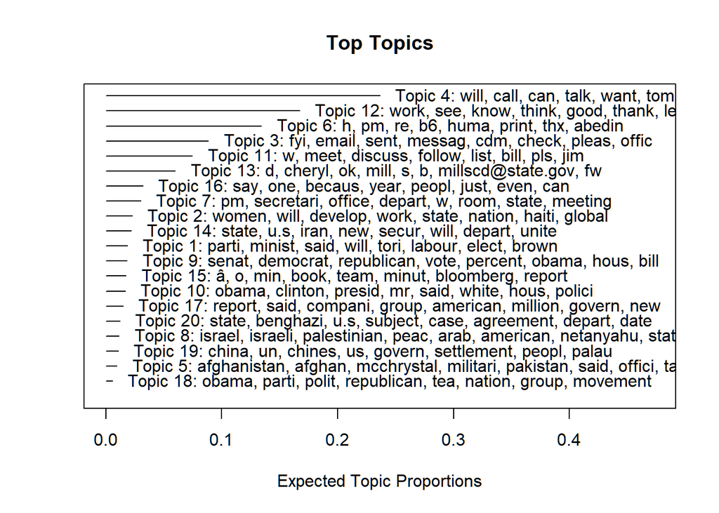

```r
plot.STM(topmod_fit2, type="summary", n = 8)
```

## create dataframe of theta values

Theta values represent the distribution of topics over the documents. Essentially, they score each document based on how well they fit each topic. The sum of each theta row (i.e. if you add up the topic scores for each document) adds up to 1. Thus, the score of each topic per document is the proportion that the topic shows up in the document. For example, document 1 could have 20% topic 1 and 5% topic 2, and so on.

```r
theta <- (topmod_fit2$theta)

topics <- paste("topic",seq(1,20))
theta <- data.frame(theta)
length(theta)
```

```
## [1] 20
```

```r
colnames(theta) <- topics
head(theta)
```

```
##        topic 1      topic 2     topic 3    topic 4      topic 5   topic 6
## 1 0.0012280806 0.0003933468 0.018096510 0.01283247 0.0005998315 0.9148469
## 2 0.0094000819 0.0074073738 0.110204370 0.14936638 0.0045663107 0.3665662
## 3 0.0005224806 0.0001849758 0.007953198 0.01698762 0.0003228560 0.9251145
## 4 0.0010137579 0.0018780538 0.060760180 0.01691762 0.0038397637 0.2018211
## 5 0.0005418232 0.0001944955 0.008207093 0.01774275 0.0003353729 0.9222207
## 6 0.0099069824 0.0115619797 0.306969510 0.20047477 0.0039825846 0.1012916
##        topic 7      topic 8      topic 9     topic 10    topic 11   topic 12
## 1 0.0023409767 0.0004114314 0.0012230610 0.0010619875 0.004171686 0.01185844
## 2 0.0182867796 0.0041286937 0.0098172932 0.0095227512 0.041482921 0.11891283
## 3 0.0005465094 0.0001490911 0.0005191241 0.0003728041 0.009272822 0.01493792
## 4 0.0021258013 0.0008668210 0.0013747544 0.0020919207 0.011295785 0.02147703
## 5 0.0005675863 0.0001552701 0.0005393533 0.0003879515 0.009684818 0.01555954
## 6 0.0204453761 0.0046599976 0.0085271783 0.0083191552 0.040941209 0.15256856
##     topic 13     topic 14     topic 15     topic 16     topic 17     topic 18
## 1 0.02497641 0.0009761150 0.0019076591 0.0004881276 0.0004279492 0.0003155921
## 2 0.09294558 0.0105123714 0.0184948357 0.0086361714 0.0049390313 0.0021937928
## 3 0.01976581 0.0002452130 0.0008761884 0.0002727171 0.0002802852 0.0003045707
## 4 0.01177453 0.0017543455 0.0051746878 0.0018966389 0.0057670302 0.0197801914
## 5 0.02037866 0.0002561259 0.0009124256 0.0002859890 0.0002924159 0.0003154155
## 6 0.06071003 0.0089947214 0.0257137847 0.0127502337 0.0072318673 0.0023359053
##       topic 19    topic 20
## 1 0.0004860899 0.001357300
## 2 0.0059035305 0.006712691
## 3 0.0003055478 0.001065751
## 4 0.0008588394 0.627531108
## 5 0.0003192437 0.001102942
## 6 0.0073157674 0.005298781
```

```r
theta <- data.matrix(theta)
```

## Sentiment scores

Here I take a list of positive and negative words. If a word that is in the dtm is positive, I give it a value of 1 and if neg, -1. Then I score each document with the val <- apply… Then, if val > 0, the doc gets a categorical value of 1 and -1 if < 0. Then, I take the average sentiment per topic.

```r
nrow(dfm)
```

```
## [1] 6608
```

```r
neg <- unlist(read.table("C:/Users/garmo/Downloads/negative-words.txt", stringsAsFactors = F))
pos <- unlist(read.table("C:/Users/garmo/Downloads/positive-words.txt", stringsAsFactors = F))

# apply numeric value to each word in dfm
words <- colnames(dfm)
score <- (1*as.numeric(words %in% pos)) +
  (-1*as.numeric(words %in% neg))

# set dfm to x to make my life easier
x <- dfm


# score each document
val <- apply(x, MARGIN = 1, FUN = function(z) sum(z*score)/sum(z))


# categorize each document as 1 (pos), -1 (neg), or 0 (neutral)
val.cat <- val
val.cat[val.cat > 0] <- 1
val.cat[val.cat < 0] <- -1


values <- rep(NA,20)
for(i in 1:20){
  values[i] <- mean(val.cat[theta[,i] > 0.2])

}

length(val.cat)
```

```
## [1] 6608
```

```r
labels <- data.frame(t(labelTopics(topmod_fit2)$frex))
colnames(labels) <- topics

labels_vec <- rep(NA,20)

for(i in 1:20){
  labels_vec[i] <- paste(unlist(labels[,i]), collapse=' ')
}

manual_labels <- c("British politics","Development of third world countries","Email and communication logistics","Confirming appointments", "Afghanistan war","Fowarding documents with quick replies","Itnerary and schedule", "Israel and Palestine","US politics and elections","Evaluations of Obama Administration","Quick updates and questions","Thanking people","Emails to Mills, Cheryl D", "Diplomacy with hostile governments (namely Iran and North Korea)","Various email attachments","Education",'Crimes and human rights violations in hostile countries','Republican politicians and conservative news outlets',"US and Chinese aid to third world countries (namely Hati and African countries","Benghazi and references to House Benghazi committee")
df <- data.frame(topic = c(1:20),'Manual labels' = manual_labels, 'FREX labels' = labels_vec, 'Average  sentiment' = values)

library(knitr)

kable(df)
```

| topic | Manual.labels | FREX.labels | Average..sentiment |
| --- | --- | --- | --- |
| 1 | British politics | tori labour cameron uup ireland brown northern | 0.2118644 |
| 2 | Development of third world countries | women develop partnership foundat global africa agricultur | 0.7337662 |
| 3 | Email and communication logistics | email fyi blackberri check sent importanc recipi | -0.0072289 |
| 4 | Confirming appointments | tomorrow u call morn can sure confirm | 0.2032497 |
| 5 | Afghanistan war | mcchrystal afghan taliban afghanistan petraeus pakistan troop | 0.0961538 |
| 6 | Fowarding documents with quick replies | hrod17@clintonemail.com abedin b6 abedinh@state.gov thx huma h | 0.0975039 |
| 7 | Itnerary and schedule | meeting en arrive rout office room briefing | 0.2611111 |
| 8 | Israel and Palestine | israel palestinian arab israeli netanyahu jerusalem jewish | -0.0384615 |
| 9 | US politics and elections | boehner senat percent voter favor democrat reid | 0.3577236 |
| 10 | Evaluations of Obama Administration | mr clinton branch gore obama carter mrs | 0.5567010 |
| 11 | Quick updates and questions | mtg jack add discuss kurt anne-mari spoke | 0.2092511 |
| 12 | Thanking people | yes draft let happi sorri good hope | 0.4240539 |
| 13 | Emails to Mills, Cheryl D | mill millscd@state.gov b1 d ok cheryl b | 0.0396270 |
| 14 | Diplomacy with hostile governments (namely Iran and North Korea) | nuclear diplomaci iran diplomat conflict weapon defens | 0.3677419 |
| 15 | Various email attachments | min o â bloomberg editori besid g | 0.0000000 |
| 16 | Education | demand student away becaus germani thing differ | 0.3389121 |
| 17 | Crimes and human rights violations in hostile countries | brother compani charl mother court investig million | 0.0275229 |
| 18 | Republican politicians and conservative news outlets | tea beck movement right-w black palin communist | 0.1153846 |
| 19 | US and Chinese aid to third world countries (namely Hati and African countries | china chines palau un princ haitian smart | 0.1935484 |
| 20 | Benghazi and references to House Benghazi committee | benghazi comm sensitive dept foia produced redactions | 0.3000000 |

```r
# representative documents, very long but included to show how we came up with manual labels
for(i in c(1:20)){
  print(paste("Topic",i))
  print(emails2$ExtractedBodyText[(findThoughts(topmod_fit2, topics = i, n = 1)$index)[[1]]])
}
```

```
## [1] "Topic 1"
## [1] "841t;SCRIPT language='JavaScript1.1' SRC=\"http://ad-\nemea.doubleclick.net/adj/N6010.133705.0666409185621/B4336495;abr=!ie;sz=468x60;click=http://ads.guardian.co.uldev\nent.ngiType=click&amp;Flight1D=143552&amp;AdlD=165203&amp;TargetlD=42700&amp;Values=3263&amp;Redirect=;\nord=bNzdlpy,bfzoc…
## [1] "Topic 2"
## [1] "Rooney)\nJune 6,2009 11:30am\nRooney (x7-7203,\nCONCEPT NOTE FOR WORLD FOOD PRIZE CEREMONY\nThursday, June 11, 2009\nThis speech is an opportunity to signal the urgency of the problem of global hunger; connect it to an array of\nglobal issues, including economic development, health and educa…
## [1] "Topic 3"
## [1] "Delivery has failed to these recipients or distribution lists:\nschwerind@state.gov\nThe recipient's e-mail address was not found in the recipient's e-mail system. Microsoft Exchange will not try to redeliver\nthis message for you. Please check the e-mail address and try resending this messa…
## [1] "Topic 4"
## [1] "I need to call Karzai, Shaun Woodward and then Robinson and McGinness and, now maybe, Kouchner. But I don't want\nto do until later today or tomorrow. Do I have time tomorrow? I will need to allocate 30 minutes to Karzai."
## [1] "Topic 5"
## [1] "After Afghan Shift, Top U.S. Civilians Face Tricky Future By MARK LANDLER WASHINGTON â\200” As General David H.\nPetraeus takes command in Afghanistan, the two top American civilian officials in the war face an uncertain and tricky\nfuture, working with a newly empowered military leader, und…
## [1] "Topic 6"
## [1] "03-23-2010.doc; Strategic Dialogue Press Clips March 24, 2010.doc; Strategic Dialogue\nPress Clips 03-25-2010.doc; Strategic Dialogue Press Clips 03-26-2010.doc; Strategic\nDialogue Press Clips 03-27-2010.doc; Strategic Dialogue Press Clips 03-28-2010.doc;\nStrategic Dialogue Press Clips 03-…
## [1] "Topic 7"
## [1] "8:00 am DEPART Private Residence *En route Washington Convention Center\n8:20 am ARRIVE Washington Convention Center\n8:30 am BILATERAL w/PM HSIEN LOONG LEE, SINGAPORE\n8:45 am S Bilateral Room 148, Washington Convention Center *Camera spray at top.\n9:00 am BILATERAL w/FM MOURAD MEDELCI, AL…
## [1] "Topic 8"
```

[output cut: 25 more lines]